# Shen Qu, 918881147

STAT564 Fall 2018 Final Exam

12/05/2018

### Question 1 (Show main steps of your work to get full points)

1. If MSE = 1.395 and n = 38 , compute the (Keep 4 or more decimal places, DO NOT round in the intermediate steps)
2. se(β ̂_4)

$$se(\mathbf{\hat\beta_4})=\sqrt{MSE\times C_{55}}=\sqrt{1.395\times0.069}=0.3102499$$

2. Cov(β ̂_2,β ̂_4)

$$Cov(\mathbf{\hat\beta_2,\hat\beta_4})=MSE\times C_{35}=1.395\times(-0.035)=-0.048825$$

3. Cor(β ̂_2,β ̂_4 )

$$se(\mathbf{\hat\beta_2})=\sqrt{MSE\times C_{33}}=\sqrt{1.395\times0.067}=0.3057205$$

$$Cor(\mathbf{\hat\beta_2,\hat\beta_4})=\frac{Cov(\mathbf{\hat\beta_2,\hat\beta_4})}{se(\mathbf{\hat\beta_2})se(\mathbf{\hat\beta_4})}=\frac{-0.048825}{0.3057205\times0.3102499}=-0.5147615$$

4. Without computing anything, explain which estimator is the most consistent.

$C_{66}=0.058$ has the smallest value. $\hatβ_5$ has the the least variance and the most consistent among the estimators.

22. Without computing anything , list the pair(s) of estimators that are positively correlated. Provide a reason.

According to the $(X'X)^{(-1)}$,

$C_{13},\ C_{17},\ C_{24},\ C_{25},\ C_{67}$ are positive.

The positively correlated pairs of parameters are

$\hatβ_0$ and $\hatβ_2$, $\hatβ_0$ and $\hatβ_6$, $\hatβ_1$ and $\hatβ_3$, $\hatβ_1$ and $\hatβ_4$, $\hatβ_5$ and $\hatβ_6$.

2. Consider the following hypothesis: $H_0: β_1=2β_3,β_2=β_3,β_5=0$
3. Report the T matrix, β vector and c vector along with their dimensions, and the rank of T matrix for testing the above hypothesis.

2. Report the values of numerator and denominator degrees of freedom for the corresponding F test. For F test, the numerator is MSR while denominator is MSE, thus

The denominator degrees of freedom is $dfE=n-(k+1)=38-(6+1)=31$

3. Show the following equation is an alternative form of the sum of squares of regreesion or model (SSR).

$$SSR=\sum_{i=1}^n(\hat y_i-\bar y)^2=\sum_{i=1}^n(\hat y_i^2-2\hat y_i\bar y+\bar y^2)=\sum_{i=1}^n\hat y_i^2-2\bar y\sum_{i=1}^n\hat y_i+\sum_{i=1}^n\bar y^2$$

$$=\sum_{i=1}^n\hat y_i^2-2\bar yn\frac{\sum_{i=1}^n\hat y_i}n+n\bar y^2=\sum_{i=1}^n\hat y_i^2-2\bar yn\bar y+n\bar y^2=\sum_{i=1}^n\hat y_i^2-n\bar y^2$$

### Question 2 (Use software to analyze the given data)

The data in the WaterFlow file are simulated data on peak rate of flow (in cfs) of water from six watersheds following storm episodes. The predictors are:

x1 : Area of watershed (mi2) x2 : Area impervious to water (mi2)  
x3 : Average slope of watershed (percent)  
x4 : Longest stream flow in watershed (1000s of feet)  
x5 : surface absorbency index, (0= complete absorbency, 100=no absorbency)  
x6 : estimated soil storage capacity (inches of water)  
x7 : Infiltration rate of water into soil (inches/hour)  
x8 : Rainfall (inches)  
x9 : Time period during which rainfall exceeded ¼ inch/hour

1. Create the matrix of scatterplots and compute the correlation matrix for all the variables. Copy and paste them here.

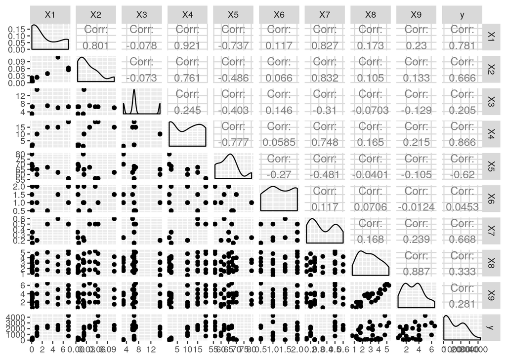

```r
library(GGally)
ggpairs(data=table_wf[c(1:10)])
```

2. Based on scatterplots and correlation, explain which predictors are significantly related to (most likely to contribute to the variation in) the response variable.

3. Fit the full model.

```r
# build the model
model_wf_full <- lm(y ~ X1 + X2 + X3 + X4 + X5 + X6 + X7 + X8 + X9, data=table_wf)
model_wf_full%>% summary()
```

```
##
## Call:
## lm(formula = y ~ X1 + X2 + X3 + X4 + X5 + X6 + X7 + X8 + X9,
##     data = table_wf)
##
## Residuals:
##      Min       1Q   Median       3Q      Max
## -1404.21  -318.77    74.73   266.66  1274.30
##
## Coefficients:
##             Estimate Std. Error t value Pr(>|t|)
## (Intercept)   292.56    4428.62   0.066   0.9480
## X1           -203.14     410.27  -0.495   0.6259
## X2           1055.78    9833.70   0.107   0.9156
## X3            -49.24     156.20  -0.315   0.7558
## X4            209.76     162.05   1.294   0.2103
## X5            -10.20      51.09  -0.200   0.8438
## X6            -24.56     303.53  -0.081   0.9363
## X7            142.78    3288.44   0.043   0.9658
## X8            511.71     209.74   2.440   0.0241 *
## X9           -301.87     172.00  -1.755   0.0945 .
## ---
## Signif. codes:  0 '***' 0.001 '**' 0.01 '*' 0.05 '.' 0.1 ' ' 1
##
## Residual standard error: 609.3 on 20 degrees of freedom
## Multiple R-squared:  0.8214, Adjusted R-squared:  0.741
## F-statistic: 10.22 on 9 and 20 DF,  p-value: 9.744e-06
```

```r
Anova(model_wf_full)
```

```
## Anova Table (Type II tests)
##
## Response: y
##            Sum Sq Df F value  Pr(>F)
## X1          91022  1  0.2452 0.62589
## X2           4279  1  0.0115 0.91557
## X3          36893  1  0.0994 0.75585
## X4         622091  1  1.6756 0.21025
## X5          14790  1  0.0398 0.84381
## X6           2430  1  0.0065 0.93632
## X7            700  1  0.0019 0.96580
## X8        2209825  1  5.9523 0.02414 *
## X9        1143622  1  3.0804 0.09455 .
## Residuals 7425127 20
## ---
## Signif. codes:  0 '***' 0.001 '**' 0.01 '*' 0.05 '.' 0.1 ' ' 1
```

```r
# vcov(model_wf_full)
```

1. Explain whether the overall model is significant at 5% significance level.

2. Explain whether assumptions of random errors and model are satisfied. If there is a violation of those, then suggest reasonable methods to correct them.

The partial regression plots do not show nonlinear patterns and hence first-order terms are good enough.

3. How much of the sum of squares is explained by rainfall, given that all the other regression coefficients are in the model?
4. Explain whether there is a problem of multicollinearity.

There is a problem of multicollinearity.

22. Interpret the estimated coefficient of rainfall predictor of the full model using question context.

It is better to remove x7 first and check whether the multicollinearity is solved. If it was not solved, then definitely, x6 has to be removed first.

4. Create a new variable using natural log of response. Then fit the full model using this new variable as response.
1. Explain whether the overall model is significant at 5% significance level.

2. Explain whether there is a problem of multicollinearity.

There is a problem of multicollinearity.

3. If you wanted to simplify this full model, explain which predictor you would eliminate first.

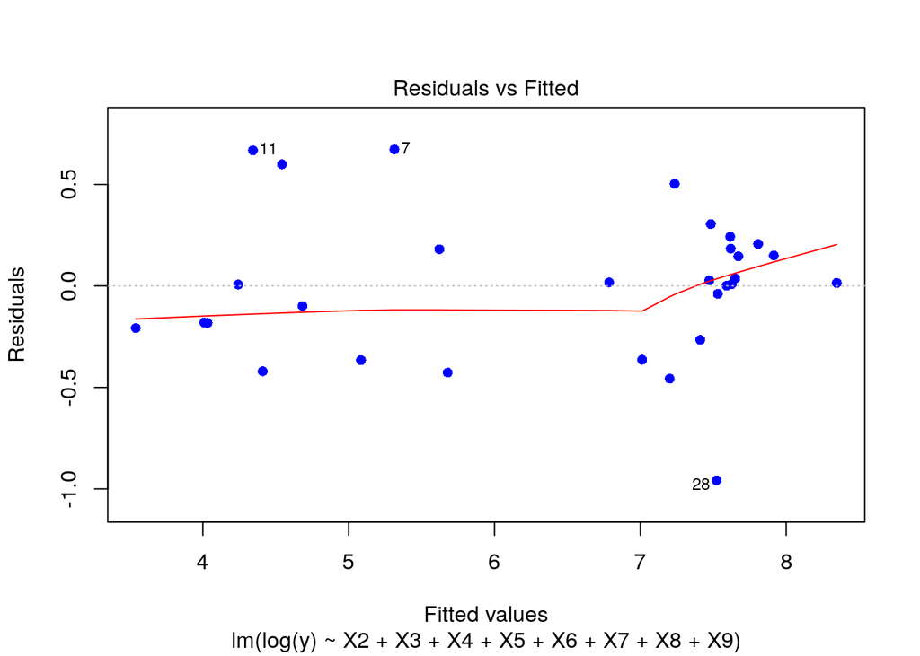

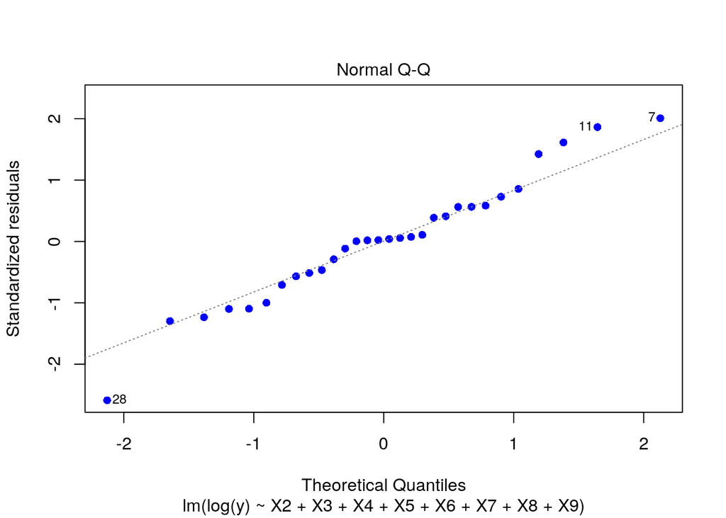

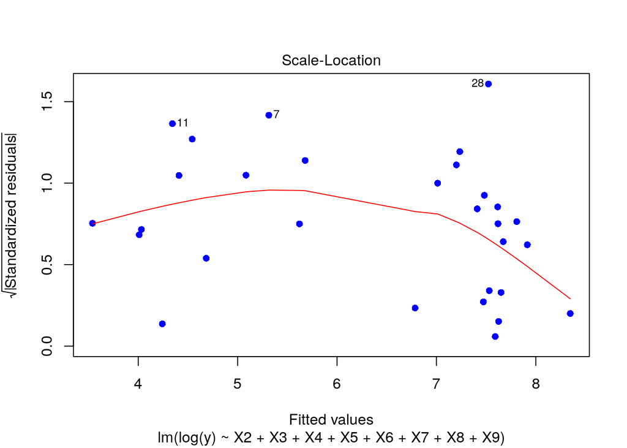

```r
plot(model_wf_reduce_log,pch=16,col="blue")
```

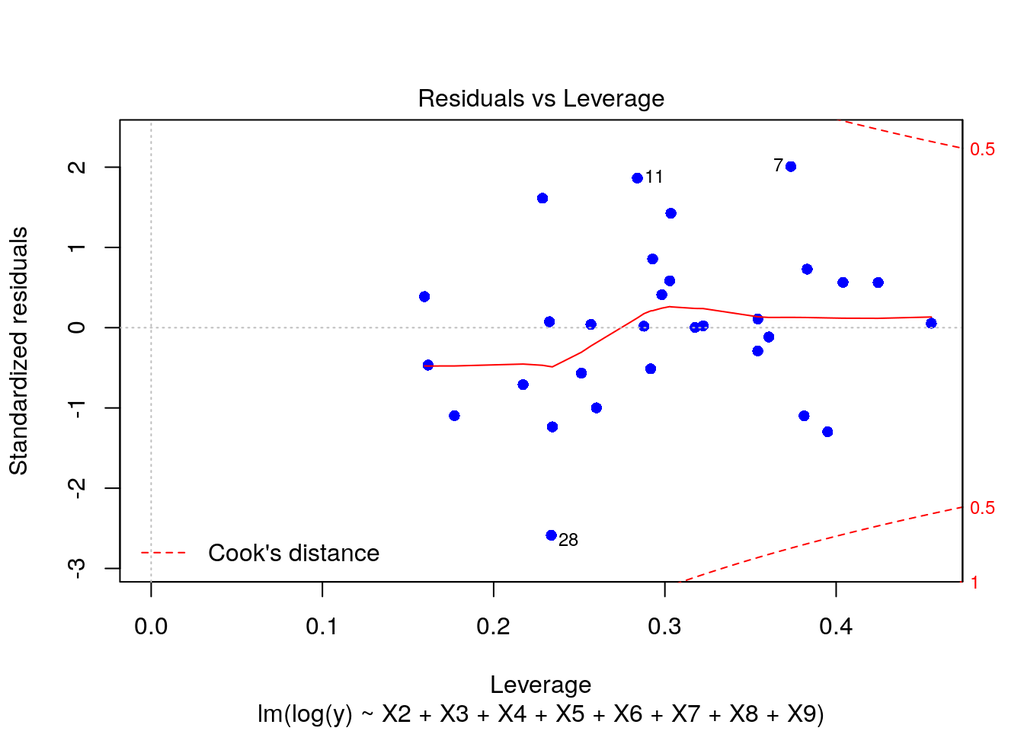

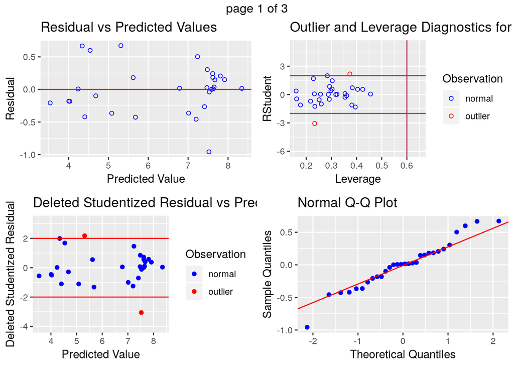

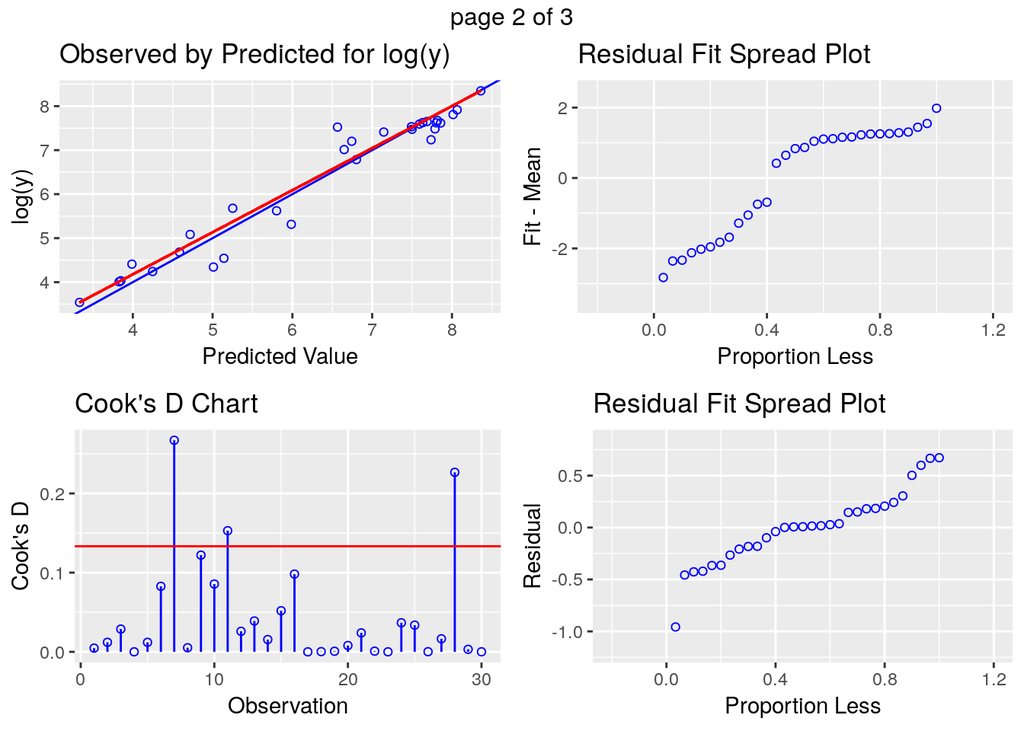

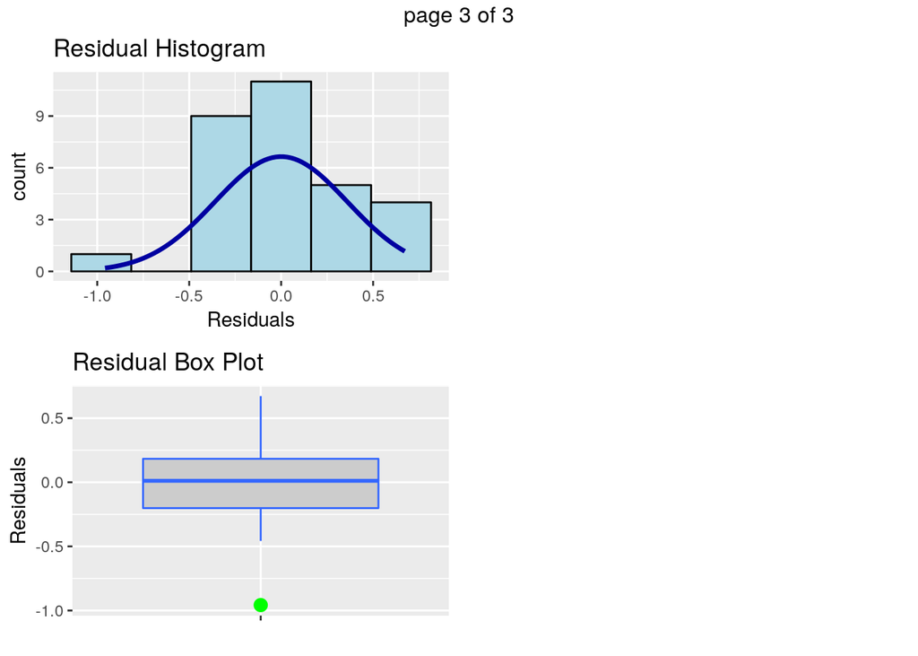

```r
ols_plot_diagnostics(model_wf_reduce_log)
```

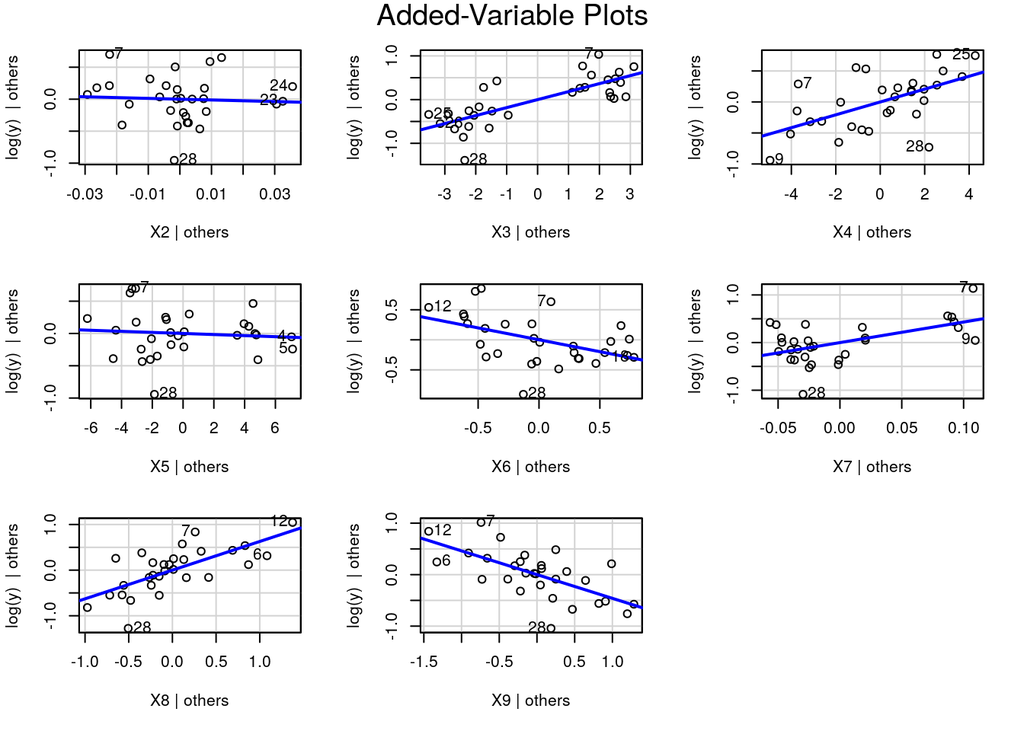

```r
avPlots(model_wf_reduce_log)
```

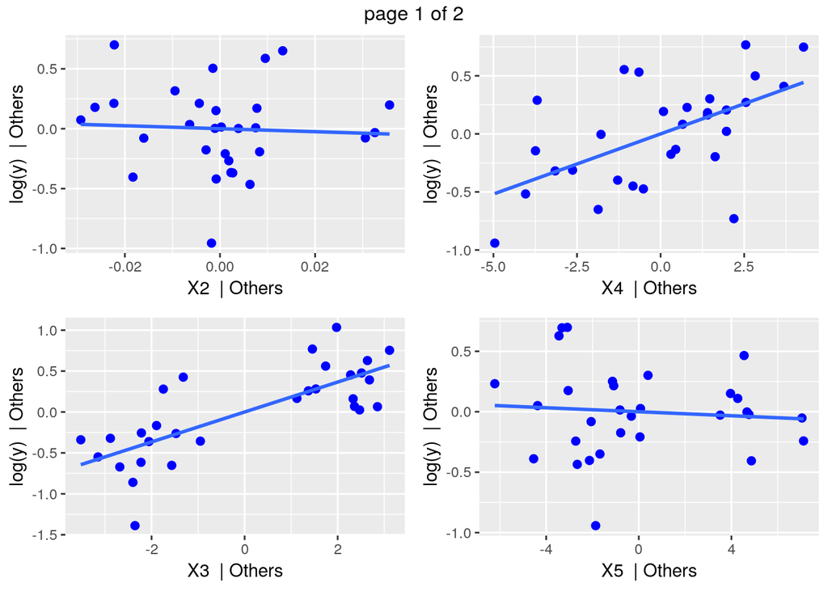

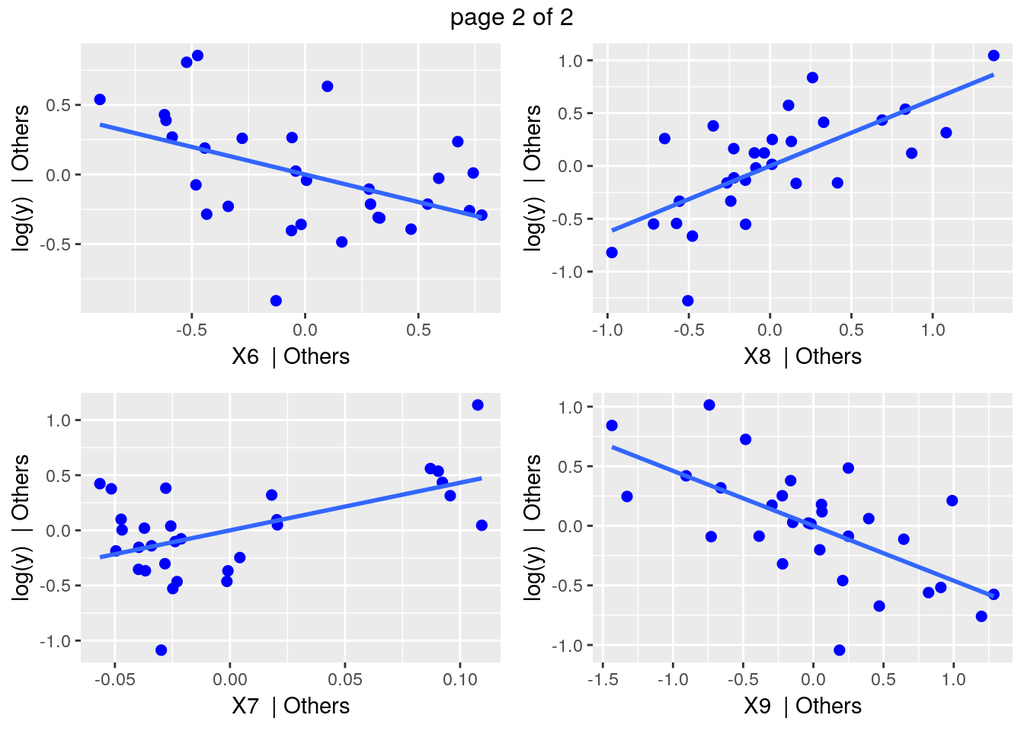

```r
ols_plot_added_variable(model_wf_reduce_log)
```

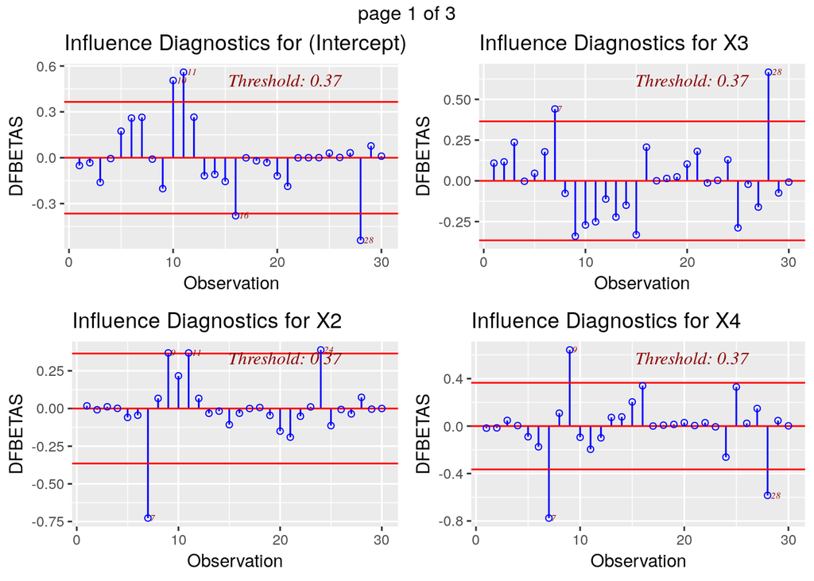

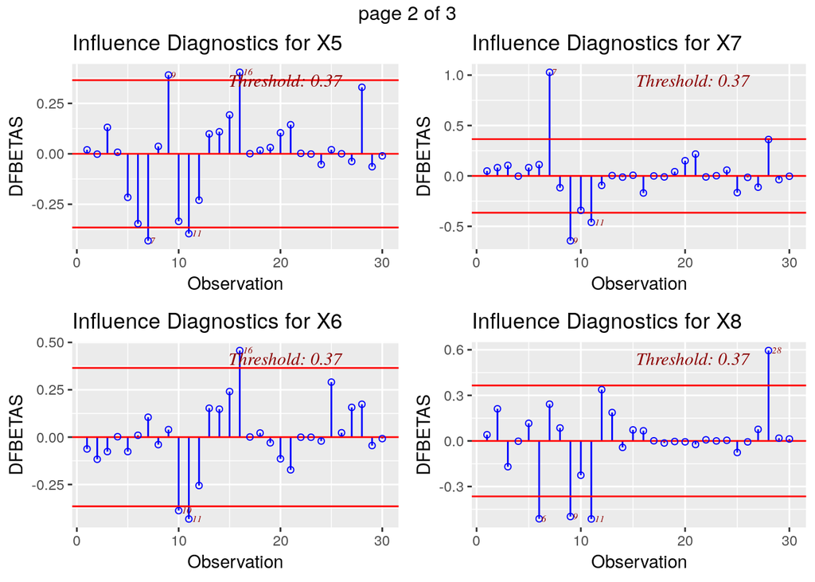

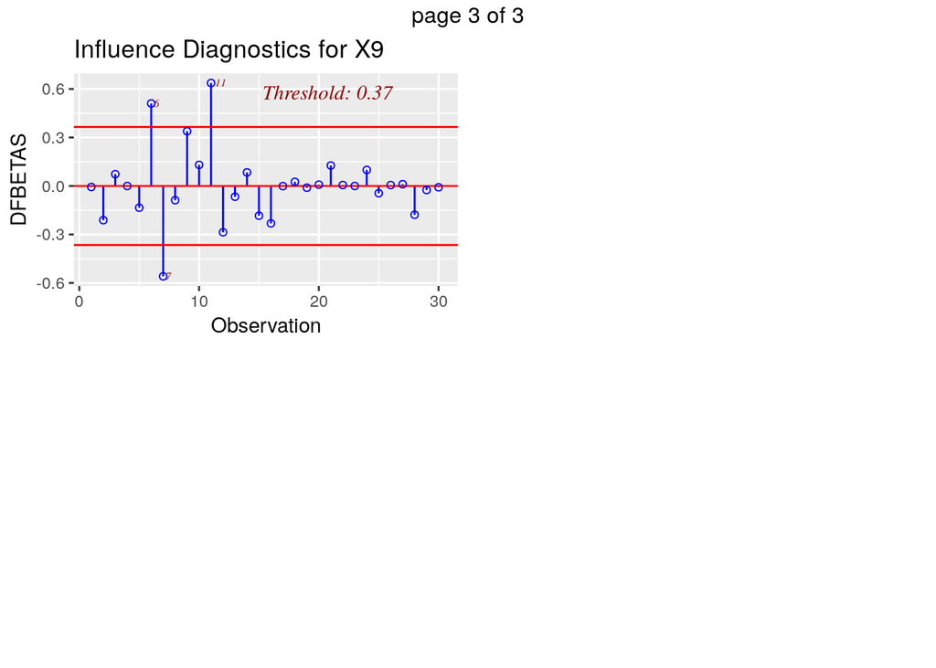

```r
ols_plot_dfbetas(model_wf_reduce_log)
```

```r
shapiro.test(rstudent(model_wf_reduce_log)) #If p-value is bigger, then no problem of non-normality #
```

```
##
##  Shapiro-Wilk normality test
##
## data:  rstudent(model_wf_reduce_log)
## W = 0.9605, p-value = 0.319
```

```r
shapiro.test(rstudent(model_wf_reduce_log))
```

```
##
##  Shapiro-Wilk normality test
##
## data:  rstudent(model_wf_reduce_log)
## W = 0.9605, p-value = 0.319
```

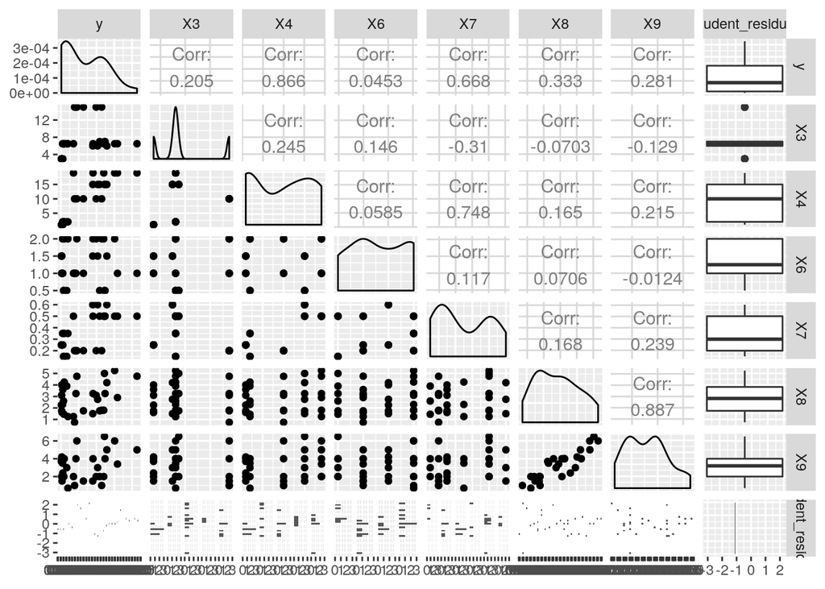

```r
table_wf_resi <- table_wf %>% mutate(student_residual=rstudent(model_wf_reduce_log))
ggpairs(data=table_wf_resi[c(10,3,4,6,7,8,9,11)])
```

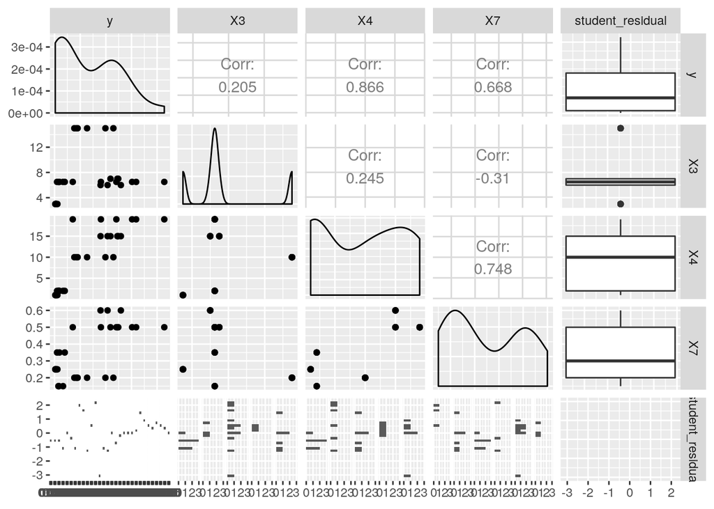

```r
table_wf_resi <- table_wf %>% mutate(student_residual=rstudent(model_wf_reduce_log))
ggpairs(data=table_wf_resi[c(10,3,4,7,11)])
```

4. Use the forward selection method to find the best model (use α=0.15) and report the final fitted model with estimated coefficients here.

```r
# Forward Selection Regression #
model_wf_none <- lm (log(y) ~ 1, data = table_wf)
step(model_wf_none, direction= "forward", scope=(~ X2 + X3 + X4 + X5 + X6 + X7 + X8 + X9), k=2)
```

```
## Start:  AIC=28.01
## log(y) ~ 1
##
##        Df Sum of Sq    RSS      AIC
## + X4    1    57.330 14.063 -18.7303
## + X5    1    37.329 34.064   7.8109
## + X2    1    30.934 40.459  12.9727
## + X7    1    24.998 46.395  17.0797
## + X3    1    16.178 55.215  22.3010
## <none>              71.393  28.0099
## + X8    1     2.908 68.484  28.7622
## + X9    1     1.253 70.139  29.4786
## + X6    1     0.209 71.184  29.9221
##
## Step:  AIC=-18.73
## log(y) ~ X4
##
##        Df Sum of Sq     RSS     AIC
## + X3    1    5.0051  9.0575 -29.928
## + X7    1    1.0122 13.0505 -18.971
## <none>              14.0626 -18.730
## + X9    1    0.2736 13.7890 -17.320
## + X8    1    0.2133 13.8493 -17.189
## + X5    1    0.1295 13.9332 -17.008
## + X2    1    0.0920 13.9707 -16.927
## + X6    1    0.0002 14.0624 -16.731
##
## Step:  AIC=-29.93
## log(y) ~ X4 + X3
##
##        Df Sum of Sq    RSS     AIC
## + X7    1   1.22979 7.8277 -32.306
## <none>              9.0575 -29.928
## + X8    1   0.52670 8.5308 -29.725
## + X2    1   0.45943 8.5981 -29.490
## + X5    1   0.20078 8.8567 -28.601
## + X6    1   0.08626 8.9712 -28.215
## + X9    1   0.00920 9.0483 -27.959
##
## Step:  AIC=-32.31
```

[output cut: 21 more lines]

```
## log(y) ~ X4 + X3 + X7 + X8 + X9
##
##        Df Sum of Sq    RSS     AIC
## + X6    1   1.05416 3.8013 -47.975
## <none>              4.8555 -42.632
## + X5    1   0.04938 4.8061 -40.939
## + X2    1   0.00046 4.8551 -40.635
##
## Step:  AIC=-47.98
## log(y) ~ X4 + X3 + X7 + X8 + X9 + X6
##
##        Df Sum of Sq    RSS     AIC
## <none>              3.8013 -47.975
## + X5    1  0.032702 3.7686 -46.234
## + X2    1  0.016977 3.7844 -46.110
```

```
##
## Call:
## lm(formula = log(y) ~ X4 + X3 + X7 + X8 + X9 + X6, data = table_wf)
##
## Coefficients:
## (Intercept)           X4           X3           X7           X8           X9           X6
##      2.6918       0.1091       0.1838       4.0850       0.6116      -0.4476      -0.3675
```

```r
# k=2 for AIC the default , k= log(n) is sometimes for BIC where n is the number of data #

ols_step_forward_aic(model_wf_reduce_log)
```

```
## Forward Selection Method
## ------------------------
##
## Candidate Terms:
##
## 1 . X2
## 2 . X3
## 3 . X4
## 4 . X5
## 5 . X6
## 6 . X7
## 7 . X8
## 8 . X9
##
##
## Variables Entered:
##
## - X4
## - X3
## - X7
## - X8
## - X9
## - X6
##
## No more variables to be added.
```

```
##
##                        Selection Summary
## ---------------------------------------------------------------
## Variable      AIC      Sum Sq     RSS       R-Sq      Adj. R-Sq
## ---------------------------------------------------------------
## X4           68.406    57.330    14.063    0.80302      0.79599
## X3           57.208    62.335     9.057    0.87313      0.86373
## X7           54.830    63.565     7.828    0.89036      0.87771
## X8           54.522    64.144     7.248    0.89848      0.88223
## X9           44.504    66.537     4.856    0.93199      0.91782
## X6           39.161    67.591     3.801    0.94675      0.93286
## ---------------------------------------------------------------
```

```r
ols_step_forward_p(model_wf_reduce_log, penter = 0.15)
```

```
## Forward Selection Method
## ---------------------------
##
## Candidate Terms:
##
## 1. X2
## 2. X3
## 3. X4
## 4. X5
## 5. X6
## 6. X7
## 7. X8
## 8. X9
##
## We are selecting variables based on p value...
##
## Variables Entered:
##
## - X4
## - X3
## - X7
##
## No more variables to be added.
##
## Final Model Output
## ------------------
##
##                         Model Summary
## -------------------------------------------------------------
## R                       0.944       RMSE               0.549
## R-Squared               0.890       Coef. Var          8.618
## Adj. R-Squared          0.878       MSE                0.301
## Pred R-Squared          0.854       MAE                0.414
## -------------------------------------------------------------
##  RMSE: Root Mean Square Error
##  MSE: Mean Square Error
##  MAE: Mean Absolute Error
##
##                                ANOVA
## -------------------------------------------------------------------
##                Sum of
##               Squares        DF    Mean Square      F         Sig.
## -------------------------------------------------------------------
## Regression     63.565         3         21.188    70.378    0.0000
## Residual        7.828        26          0.301
## Total          71.393        29
## -------------------------------------------------------------------
##
##                                  Parameter Estimates
## -------------------------------------------------------------------------------------
##       model     Beta    Std. Error    Std. Beta      t       Sig      lower    upper
## -------------------------------------------------------------------------------------
## (Intercept)    2.872         0.547                 5.254    0.000     1.748    3.995
##          X4    0.122         0.033        0.559    3.730    0.001     0.055    0.189
##          X3    0.168         0.040        0.435    4.165    0.000     0.085    0.251
##          X7    3.106         1.537        0.309    2.021    0.054    -0.053    6.266
## -------------------------------------------------------------------------------------
```

```
##
##                            Selection Summary
## ------------------------------------------------------------------------
##         Variable                  Adj.
## Step    Entered     R-Square    R-Square     C(p)        AIC       RMSE
## ------------------------------------------------------------------------
##    1    X4            0.8030      0.7960    52.5895    68.4060    0.7087
##    2    X3            0.8731      0.8637    26.6181    57.2082    0.5792
##    3    X7            0.8904      0.8777    21.7454    54.8305    0.5487
## ------------------------------------------------------------------------
```

5. Use the backward elimination method to find the best model (use α=0.05) and report the final fitted model with estimated coefficients here.

```r
# Backward Elimination Regression #
step(model_wf_reduce_log, direction = "backward")
```

```
## Start:  AIC=-44.32
## log(y) ~ X2 + X3 + X4 + X5 + X6 + X7 + X8 + X9
##
##        Df Sum of Sq    RSS     AIC
## - X2    1    0.0110 3.7686 -46.234
## - X5    1    0.0267 3.7844 -46.110
## <none>              3.7577 -44.322
## - X6    1    1.0447 4.8023 -38.963
## - X7    1    1.5520 5.3097 -35.950
## - X4    1    1.8469 5.6046 -34.328
## - X9    1    2.8341 6.5918 -29.461
## - X8    1    3.4848 7.2425 -26.637
## - X3    1    5.0955 8.8532 -20.613
##
## Step:  AIC=-46.23
## log(y) ~ X3 + X4 + X5 + X6 + X7 + X8 + X9
##
##        Df Sum of Sq    RSS     AIC
## - X5    1    0.0327 3.8013 -47.975
## <none>              3.7686 -46.234
## - X6    1    1.0375 4.8061 -40.939
## - X4    1    1.8741 5.6428 -36.125
## - X7    1    1.9036 5.6722 -35.968
## - X9    1    2.8353 6.6040 -31.406
## - X8    1    3.4744 7.2430 -28.635
## - X3    1    5.1264 8.8951 -22.471
##
## Step:  AIC=-47.98
## log(y) ~ X3 + X4 + X6 + X7 + X8 + X9
##
##        Df Sum of Sq    RSS     AIC
## <none>              3.8013 -47.975
## - X6    1    1.0542 4.8555 -42.632
## - X7    1    1.8739 5.6752 -37.953
## - X9    1    2.8256 6.6270 -33.302
## - X4    1    2.9771 6.7784 -32.624
## - X8    1    3.5182 7.3195 -30.320
## - X3    1    5.3653 9.1666 -23.569
```

```
##
## Call:
## lm(formula = log(y) ~ X3 + X4 + X6 + X7 + X8 + X9, data = table_wf)
##
## Coefficients:
## (Intercept)           X3           X4           X6           X7           X8           X9
##      2.6918       0.1838       0.1091      -0.3675       4.0850       0.6116      -0.4476
```

```r
ols_step_backward_aic(model_wf_reduce_log)
```

```
## Backward Elimination Method
## ---------------------------
##
## Candidate Terms:
##
## 1 . X2
## 2 . X3
## 3 . X4
## 4 . X5
## 5 . X6
## 6 . X7
## 7 . X8
## 8 . X9
##
##
## Variables Removed:
##
## - X2
## - X5
##
## No more variables to be removed.
```

```
##
##
##                   Backward Elimination Summary
## ---------------------------------------------------------------
## Variable       AIC       RSS     Sum Sq     R-Sq      Adj. R-Sq
## ---------------------------------------------------------------
## Full Model    42.815    3.758    67.635    0.94737      0.92731
## X2            40.902    3.769    67.624    0.94721      0.93042
## X5            39.161    3.801    67.591    0.94675      0.93286
## ---------------------------------------------------------------
```

```r
ols_step_backward_p(model_wf_reduce_log, penter = 0.05)
```

```
## Backward Elimination Method
## ---------------------------
##
## Candidate Terms:
##
## 1 . X2
## 2 . X3
## 3 . X4
## 4 . X5
## 5 . X6
## 6 . X7
## 7 . X8
## 8 . X9
##
## We are eliminating variables based on p value...
##
## Variables Removed:
##
## - X2
## - X5
##
## No more variables satisfy the condition of p value = 0.3
##
##
## Final Model Output
## ------------------
##
##                         Model Summary
## -------------------------------------------------------------
## R                       0.973       RMSE               0.407
## R-Squared               0.947       Coef. Var          6.385
## Adj. R-Squared          0.933       MSE                0.165
## Pred R-Squared          0.908       MAE                0.273
## -------------------------------------------------------------
##  RMSE: Root Mean Square Error
##  MSE: Mean Square Error
##  MAE: Mean Absolute Error
##
##                                ANOVA
## -------------------------------------------------------------------
##                Sum of
##               Squares        DF    Mean Square      F         Sig.
## -------------------------------------------------------------------
## Regression     67.591         6         11.265     68.16    0.0000
## Residual        3.801        23          0.165
## Total          71.393        29
## -------------------------------------------------------------------
##
##                                   Parameter Estimates
## ----------------------------------------------------------------------------------------
##       model      Beta    Std. Error    Std. Beta      t        Sig      lower     upper
## ----------------------------------------------------------------------------------------
## (Intercept)     2.692         0.445                  6.046    0.000     1.771     3.613
##          X3     0.184         0.032        0.476     5.698    0.000     0.117     0.251
##          X4     0.109         0.026        0.499     4.244    0.000     0.056     0.162
##          X6    -0.368         0.146       -0.133    -2.526    0.019    -0.669    -0.066
##          X7     4.085         1.213        0.406     3.367    0.003     1.575     6.595
##          X8     0.612         0.133        0.493     4.614    0.000     0.337     0.886
##          X9    -0.448         0.108       -0.450    -4.135    0.000    -0.672    -0.224
## ----------------------------------------------------------------------------------------
```

```
##
##
##                           Elimination Summary
## -----------------------------------------------------------------------
##         Variable                  Adj.
## Step    Removed     R-Square    R-Square     C(p)       AIC       RMSE
## -----------------------------------------------------------------------
##    1    X2            0.9472      0.9304    7.0612    40.9019    0.4139
##    2    X5            0.9468      0.9329    5.2440    39.1611    0.4065
## -----------------------------------------------------------------------
```

```r
k<- ols_step_both_aic(model_wf_reduce_log)
```

```
## Stepwise Selection Method
## -------------------------
##
## Candidate Terms:
##
## 1 . X2
## 2 . X3
## 3 . X4
## 4 . X5
## 5 . X6
## 6 . X7
## 7 . X8
## 8 . X9
##
##
## Variables Entered/Removed:
##
## - X4 added
## - X3 added
## - X7 added
## - X8 added
## - X9 added
## - X6 added
##
## No more variables to be added or removed.
```

```r
k
```

```
##
##
##                               Stepwise Summary
## --------------------------------------------------------------------------
## Variable     Method      AIC       RSS      Sum Sq     R-Sq      Adj. R-Sq
## --------------------------------------------------------------------------
## X4          addition    68.406    14.063    57.330    0.80302      0.79599
## X3          addition    57.208     9.057    62.335    0.87313      0.86373
## X7          addition    54.830     7.828    63.565    0.89036      0.87771
## X8          addition    54.522     7.248    64.144    0.89848      0.88223
## X9          addition    44.504     4.856    66.537    0.93199      0.91782
## X6          addition    39.161     3.801    67.591    0.94675      0.93286
## --------------------------------------------------------------------------
```

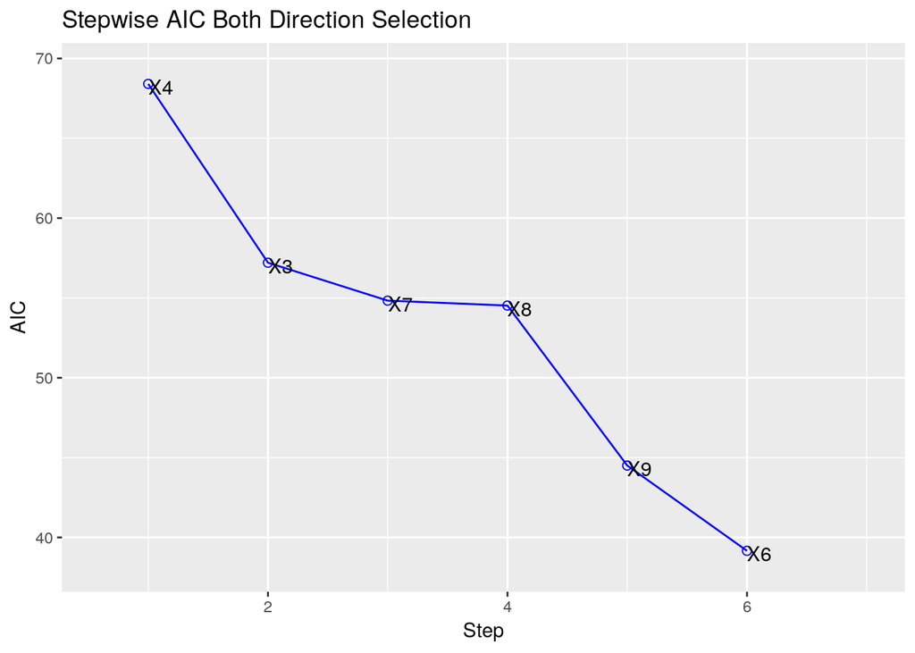

```r
plot(k)
```

```r
k <- ols_step_both_p(model_wf_reduce_log)
```

```
## Stepwise Selection Method
## ---------------------------
##
## Candidate Terms:
##
## 1. X2
## 2. X3
## 3. X4
## 4. X5
## 5. X6
## 6. X7
## 7. X8
## 8. X9
##
## We are selecting variables based on p value...
##
## Variables Entered/Removed:
##
## - X4 added
## - X3 added
## - X7 added
##
## No more variables to be added/removed.
##
##
## Final Model Output
## ------------------
##
##                         Model Summary
## -------------------------------------------------------------
## R                       0.944       RMSE               0.549
## R-Squared               0.890       Coef. Var          8.618
## Adj. R-Squared          0.878       MSE                0.301
## Pred R-Squared          0.854       MAE                0.414
## -------------------------------------------------------------
##  RMSE: Root Mean Square Error
##  MSE: Mean Square Error
##  MAE: Mean Absolute Error
##
##                                ANOVA
## -------------------------------------------------------------------
##                Sum of
##               Squares        DF    Mean Square      F         Sig.
## -------------------------------------------------------------------
## Regression     63.565         3         21.188    70.378    0.0000
## Residual        7.828        26          0.301
## Total          71.393        29
## -------------------------------------------------------------------
##
##                                  Parameter Estimates
## -------------------------------------------------------------------------------------
##       model     Beta    Std. Error    Std. Beta      t       Sig      lower    upper
## -------------------------------------------------------------------------------------
## (Intercept)    2.872         0.547                 5.254    0.000     1.748    3.995
##          X4    0.122         0.033        0.559    3.730    0.001     0.055    0.189
##          X3    0.168         0.040        0.435    4.165    0.000     0.085    0.251
##          X7    3.106         1.537        0.309    2.021    0.054    -0.053    6.266
## -------------------------------------------------------------------------------------
```

```r
k
```

```
##
##                              Stepwise Selection Summary
## ------------------------------------------------------------------------------------
##                      Added/                   Adj.
## Step    Variable    Removed     R-Square    R-Square     C(p)        AIC       RMSE
## ------------------------------------------------------------------------------------
##    1       X4       addition       0.803       0.796    52.5890    68.4060    0.7087
##    2       X3       addition       0.873       0.864    26.6180    57.2082    0.5792
##    3       X7       addition       0.890       0.878    21.7450    54.8305    0.5487
## ------------------------------------------------------------------------------------
```

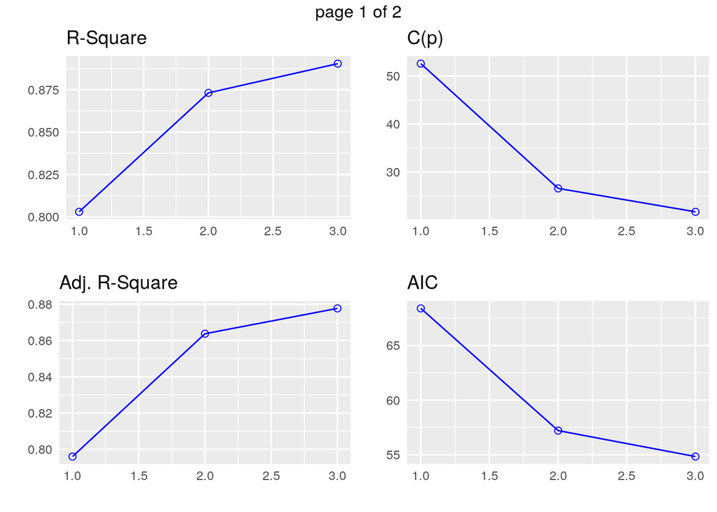

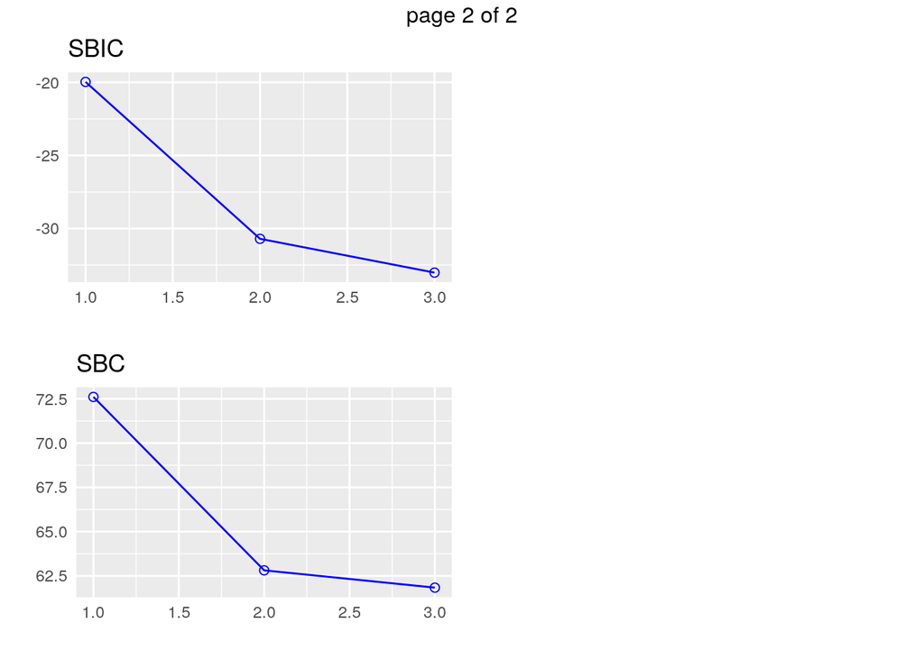

```r
plot(k)
```